# Fitting ARIMA models

19 Jan 2021

## Points from Thursday

ARIMA models

- An approach for fitting time series data by differencing the data to produce a new stationary time series
- Works because any stationary time series can be modeled as a ARMA process (Wold Decomposition)

## Box-Jenkins method for fitting ARIMA model

1. Make data stationarity by differencing the data (if required)
2. Determine AR and MA lags via model selection
3. Estimate the parameters (fit the model)
4. Assess the residuals for problems

## Approaches for non-stationary time series data

ARIMA models are one approach for fitting non-stationary time series data.

Other approaches (and what we’ll be mostly cover in this class)

- Regression with AR or ARMA errors
- Stochastic level models (type of hidden random walk model)
- ARMAX models: \(x_t = b x_{t-1} + \beta \text{covariates} + \text{error}\)

## Let’s see an example

AR(1) data: \(x_t = 0.8 x_{t-1} + e_t\)

Trend: \(z_t = f(t, t^2, t^3)\), some 3rd order polynomial

Data: \(y_t = z_t + x_t\), Trend + AR(1)

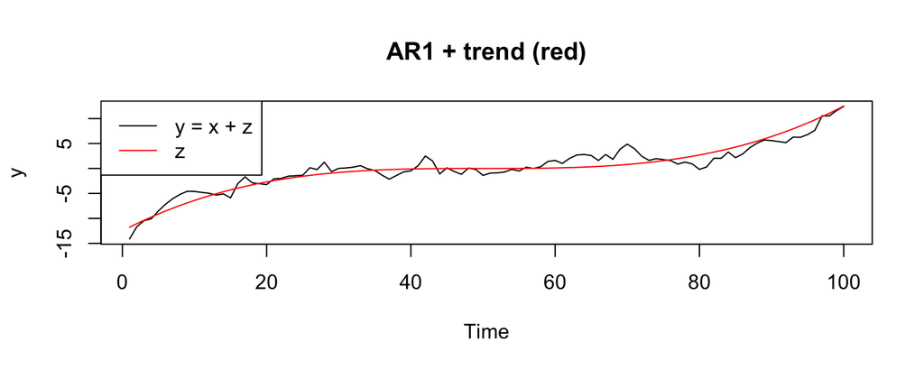

## ARIMA Approach

```r
t1 <- 1:90
fit <- forecast::auto.arima(y[t1])
fit
```

```
## Series: y[t1]
## ARIMA(0,1,0) with drift
##
## Coefficients:
##        drift
##       0.2212
## s.e.  0.1019
##
## sigma^2 = 0.9339:  log likelihood = -122.74
## AIC=249.47   AICc=249.61   BIC=254.45
```

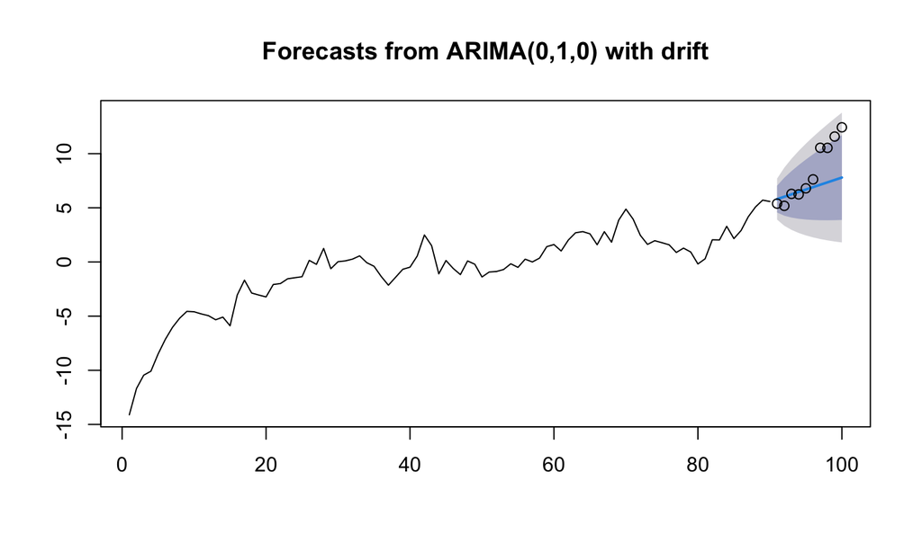

```r
plot(forecast::forecast(fit, h=10))
t2 <- 91:100
points(t2, y[t2])
```

## Polynomial regression w ARMA errors

Use `xreg` to do this. Fits \(y_t = \alpha + \beta_1 t + \beta_2 t^2 + \beta_3 t^3 + e_t\)

```r
t1=1:90
xreg <- cbind(t1=t, t2=t^2, t3=t^3) # use poly(t, 3) in practice
fit <- forecast::auto.arima(y[t1], xreg=xreg[t1,], d=0)
fit
```

```
## Series: y[t1]
## Regression with ARIMA(1,0,0) errors
##
## Coefficients:
##          ar1  intercept      t1       t2     t3
##       0.7634   -13.1034  0.8063  -0.0155  1e-04
## s.e.  0.0712     1.2643  0.1097   0.0024  0e+00
##
## sigma^2 = 0.7955:  log likelihood = -115.28
## AIC=242.55   AICc=243.56   BIC=257.55
```

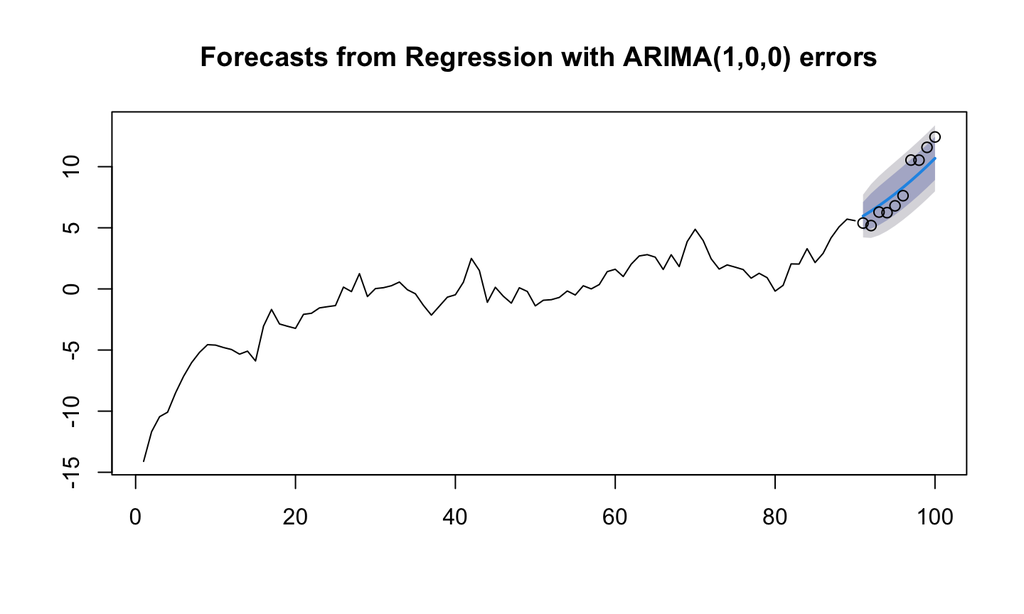

```r
t2=91:100
plot(forecast::forecast(fit, h=10, xreg=xreg[t2,]))
points(t2, y[t2])
```

## SARIMA: Seasonal ARIMA model

### Load the chinook salmon data set

It has WA and OR data.

```r
library(atsalibrary)
head(chinook.month)
```

```
##   Year Month Species State log.metric.tons metric.tons  Value
## 1 1990   Jan Chinook    WA        3.397858        29.9 108515
## 2 1990   Feb Chinook    WA        3.808882        45.1 308707
## 3 1990   Mar Chinook    WA        3.511545        33.5 200535
## 4 1990   Apr Chinook    WA        4.248495        70.0 431136
## 5 1990   May Chinook    WA        5.200705       181.4 859988
## 6 1990   Jun Chinook    WA        4.371976        79.2 419635
```

The data are monthly and start in January 1990. To make this into a ts object do

```r
chinookts <- ts(chinook.month$log.metric.tons[chinook.month$State=="WA"],
                start=c(1990,1),
                frequency=12)
```

`start` is the year and month and frequency is the number of months in the year.

Use `?ts` to see more examples of how to set up ts objects.

## Plot seasonal data

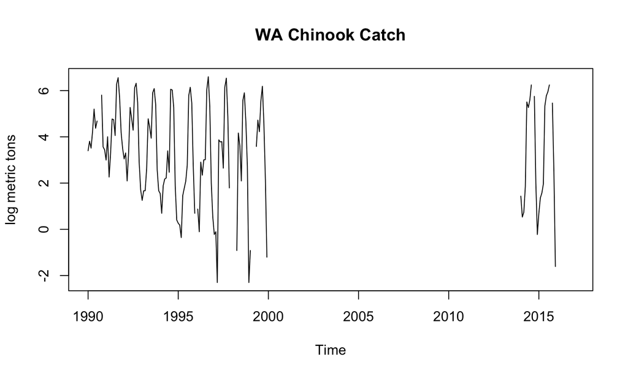

A seasonal difference is \(x_t\) minus \(x_{t-s}\), e.g. chinook data January 1990 - chinook data January 1989.

\[z_t = x_t - x_{t-12}\]

This will remove the seasonality.

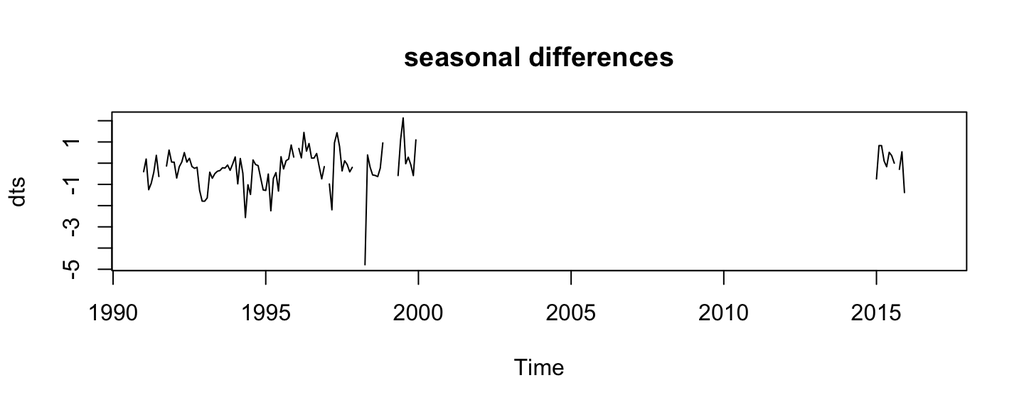

```r
dts <- diff(chinookts, lag=12)
plot(dts, main="seasonal differences")
```

## SARIMA structure

I = differencing to produce stationarity

SARMA = AR & MA with seasonal lags.

Basic structure of a SARIMA(1) model is AR(non-seasonal) + AR(seasonal)

\[z_t = \phi_1 z_{t-1} + \Phi_1 z_{t-12} - \phi_1\Phi_1 z_{t-13}\]

So feb 90 - feb 89 (\(z_t\)) is, potentially, correlated with jan 90 - jan 89 (\(z_{t-1}\)) and feb 89 - feb 88 (\(z_{t-12}\))

## Notation

ARIMA (p,d,q)(ps,ds,qs)s

ARIMA (non-seasonal part)(seasonal part)Frequency

- ARIMA (non-seasonal) means \(z_t\) correlated with \(z_{t-1}\)
- ARIMA (seasonal) means \(z_t\) correlated with \(z_{t-s}\)

## Examples

**ARIMA (1,0,0)(1,1,0)[12]**

1. Look at \(d\)’s to figure out \(z_t\). Just a seasonal difference.

\[z_t = x_t - x_{t-12}\]

1. Write out the AR parts with \(z_t\)

\[z_t = \phi_1 z_{t-1} + \Phi_1 z_{t-12} - \phi_1\Phi_1 z_{t-13} + w_t\]

1. Write out the MA parts, the \(w_t\). No MA in this model. \(w_t\) is white noise.

\[w_t = e_t\]

## Seasonal random walk model

**ARIMA(0,0,0)(0,1,0)[12] with drift**

1. Look at \(d\) and any ‘with drift’ to figure out \(z_t\)

\[z_t = x_t - x_{t-12} + m\]

No AR parts. \(z_t = w_t\)

No MA part, so \(w_t = e_t\) (white noise)

January 1990 = January 1989 + constant mean

## airline model

**ARIMA(0, 1, 1)(0, 1, 1)[12]**

Figure out \(z_t\).

\[z_t = (x_t - x_{t-12}) - (x_{t-1} - x_{t-13})\]

Write out the AR parts with \(z_t\). No AR part.

\[z_t = w_t\]

Write out the MA parts, the \(w_t\).

\[w_t = e_t - \theta_1 e_{t-1} - \Theta_1 e_{t-12} + \theta_1\Theta_1 e_{t-13}\]

## `auto.arima()` for seasonal ts

`auto.arima()` will recognize that our data has season and fit a seasonal ARIMA model to our data by default. We will fit to 1990 to 2000 data.

```r
dat <- window(chinookts, start=c(1990,1), end=c(2000,12))
fit <- forecast::auto.arima(dat)
fit
```

```
## Series: dat
## ARIMA(1,0,0)(0,1,2)[12] with drift
##
## Coefficients:
##          ar1     sma1     sma2    drift
##       0.3222  -0.2499  -0.2151  -0.0246
## s.e.  0.1077   0.1253   0.1348   0.0064
##
## sigma^2 = 0.7523:  log likelihood = -126.74
## AIC=263.49   AICc=264.08   BIC=276.9
```

**ARIMA(1,0,0)(0,1,2)[12] with drift**

- One seasonal difference
- “with drift” mean of differenced data is not equal to 0
- \(z_t\) is correlated with \(z_{t-1}\)
- error is correlated (MA) across seasonal differences

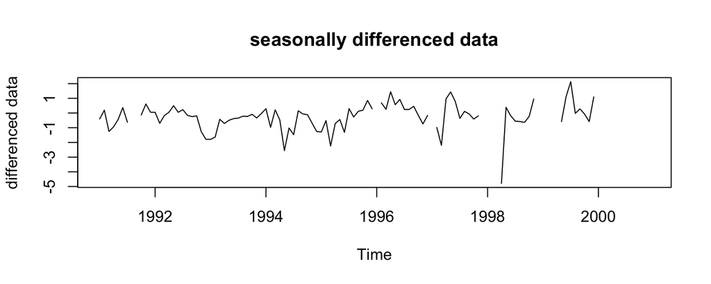

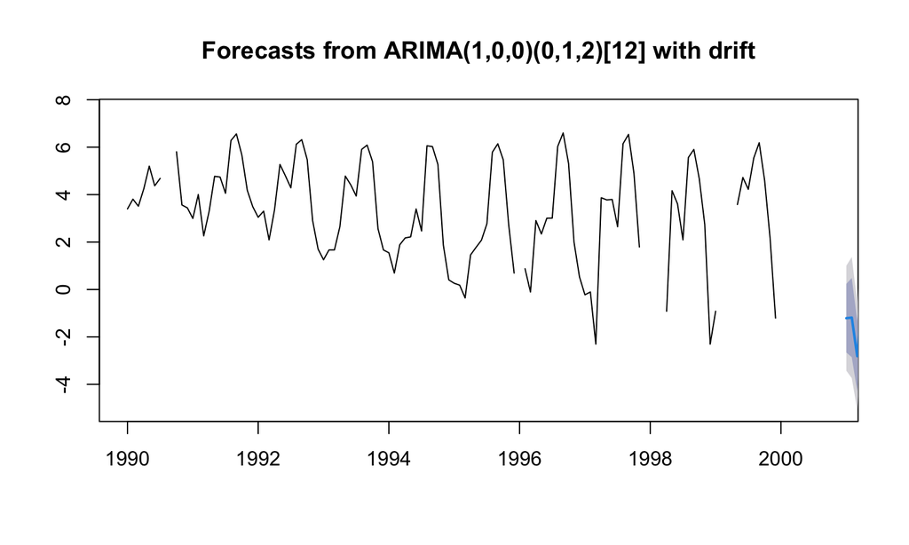

```r
fr <- forecast::forecast(fit, h=10)
plot(fr)
```

## Summary for SARIMA models

Basic steps for identifying a seasonal model. **forecast** automates most of this.

- Make your data into a ts object with frequency specified.
- Plot your data. Look for trend, seasonality and random walks.
- Use differencing to remove season and trend.
- Examine the ACF and PACF of the differenced data.
  - Look for patterns (spikes) at seasonal lags
- Estimate likely models and compare with model selection criteria (or cross-validation). Use `TRACE=TRUE`
- Do residual checks